# GO with clusters

Group 1

2023-07-11

```r
suppressPackageStartupMessages({
  library(GenomicRanges)
  library(epiwraps)
  library(ggplot2)
  library(rGREAT)
  library(AnnotationHub)
  library(MotifDb)
  #library(memes)
  library(universalmotif)
  library(ensembldb)
  library(Rsamtools)
  library(motifmatchr)
  library(sechm)
  library(BiocParallel)
  library(chromVAR) # for motif accessibility estimation
  library(SummarizedExperiment) # data structure
  library(limma) # for statistical analysis
  library(bsseq)
  library(edgeR)
  library(DMRcate)
  library(rtracklayer)
  library(pheatmap)
  library(viridis)
  library(data.table)
  library(BRGenomics)
  library(BioMartGOGeneSets) # for GO analysis
  library(BSgenome.Rnorvegicus.UCSC.rn7)
  library(cowplot)
})
```

```
## See system.file("LICENSE", package="MotifDb") for use restrictions.
```

# Clustering

There we just take the clusters from the previous file to perform the GO analysis.

```r
# new names
# Rename peaks
new_names_3_1 <- c("FS30 GR", "BLAM GR", "BLPM GR")
new_names_3_2 <- c("FS30 MR", "BLAM MR", "BLPM MR")
# prepare regions and tracks
tracks_1 <- list.files(path = "D:\\bioinformatics_final_project\\Laura\\Bw", pattern="GR.bw$", full = TRUE)
region_files_1 <- list.files(path = "D:\\bioinformatics_final_project\\Laura\\NarrowPeaks",full=TRUE, pattern = "GR_peaks.narrowPeak")
peaks_1 <- lapply(region_files_1, FUN=rtracklayer::import)
regions_1 <- reduce(unlist(GRangesList(peaks_1)))
tracks_2 <- list.files(path = "D:\\bioinformatics_final_project\\Laura\\Bw", pattern="MR.bw$", full = TRUE)
region_files_2 <- list.files(path = "D:\\bioinformatics_final_project\\Laura\\NarrowPeaks",full=TRUE, pattern = "MR_peaks.narrowPeak")
peaks_2 <- lapply(region_files_2, FUN=rtracklayer::import)
regions_2 <- reduce(unlist(GRangesList(peaks_2)))
# build matrix and plot
ml_1 <- signal2Matrix(tracks_1, regions_1, extend=2000)
```

```
## Reading D:\bioinformatics_final_project\Laura\Bw/SRX5371942.GSM3602775.Late_afternoon_baseline_GR.bw
```

```
## Reading D:\bioinformatics_final_project\Laura\Bw/SRX5371944.GSM3602751.Early_morning_baseline_GR.bw
```

```
## Reading D:\bioinformatics_final_project\Laura\Bw/SRX5371947.GSM3602754.Acute_stress_GR.bw
```

```
## Reading D:\bioinformatics_final_project\Laura\Bw/SRX5371950.GSM3602757.Late_afternoon_baseline_GR.bw
```

```
## Reading D:\bioinformatics_final_project\Laura\Bw/SRX5371953.GSM3602760.Early_morning_baseline_GR.bw
```

```
## Reading D:\bioinformatics_final_project\Laura\Bw/SRX5371956.GSM3602763.Acute_stress_GR.bw
```

```
## Reading D:\bioinformatics_final_project\Laura\Bw/SRX5371959.GSM3602766.Late_afternoon_baseline_GR.bw
```

```
## Reading D:\bioinformatics_final_project\Laura\Bw/SRX5371962.GSM3602769.Early_morning_baseline_GR.bw
```

```
## Reading D:\bioinformatics_final_project\Laura\Bw/SRX5371965.GSM3602772.Acute_stress_GR.bw
```

```
## Reading D:\bioinformatics_final_project\Laura\Bw/SRX5371969.GSM3602778.Early_morning_baseline_GR.bw
```

```
## Reading D:\bioinformatics_final_project\Laura\Bw/SRX5371972.GSM3602781.Acute_stress_GR.bw
```

```
## Reading D:\bioinformatics_final_project\Laura\Bw/SRX5371975.GSM3602784.Late_afternoon_baseline_GR.bw
```

```r
nf_1 <- rep(1, length(ml_1)) # see differential analysis file for the choice of the normalization factor
mln_1 <- rescaleSignalMatrices(ml_1, nf_1)
names(mln_1) <- c("GR_peaks_BLPM_A", "GR_peaks_BLAM_A", "GR_peaks_FS30_A", "GR_peaks_BLPM_B", "GR_peaks_BLAM_B", "GR_peaks_FS30_B", "GR_peaks_BLPM_C", "GR_peaks_BLAM_C", "GR_peaks_FS30_C", "GR_peaks_BLAM_D", "GR_peaks_FS30_D", "GR_peaks_BLPM_D")
smMerged_1 <- list(
  BLAM_GR = mergeSignalMatrices(mln_1[c("GR_peaks_BLAM_A","GR_peaks_BLAM_B", "GR_peaks_BLAM_C", "GR_peaks_BLAM_D")]),
  BLPM_GR = mergeSignalMatrices(mln_1[c("GR_peaks_BLPM_A","GR_peaks_BLPM_B", "GR_peaks_BLPM_C", "GR_peaks_BLPM_D")]),
  FS30_GR = mergeSignalMatrices(mln_1[c("GR_peaks_FS30_A","GR_peaks_FS30_B", "GR_peaks_FS30_C", "GR_peaks_FS30_D")]))
ml_2 <- signal2Matrix(tracks_2, regions_2, extend=2000)
```

```
## Reading D:\bioinformatics_final_project\Laura\Bw/SRX5371943.GSM3602776.Late_afternoon_baseline_MR.bw
```

```
## Reading D:\bioinformatics_final_project\Laura\Bw/SRX5371945.GSM3602752.Early_morning_baseline_MR.bw
```

```
## Reading D:\bioinformatics_final_project\Laura\Bw/SRX5371948.GSM3602755.Acute_stress_MR.bw
```

```
## Reading D:\bioinformatics_final_project\Laura\Bw/SRX5371951.GSM3602758.Late_afternoon_baseline_MR.bw
```

```
## Reading D:\bioinformatics_final_project\Laura\Bw/SRX5371954.GSM3602761.Early_morning_baseline_MR.bw
```

```
## Reading D:\bioinformatics_final_project\Laura\Bw/SRX5371957.GSM3602764.Acute_stress_MR.bw
```

```
## Reading D:\bioinformatics_final_project\Laura\Bw/SRX5371960.GSM3602767.Late_afternoon_baseline_MR.bw
```

```
## Reading D:\bioinformatics_final_project\Laura\Bw/SRX5371963.GSM3602770.Early_morning_baseline_MR.bw
```

```
## Reading D:\bioinformatics_final_project\Laura\Bw/SRX5371966.GSM3602773.Acute_stress_MR.bw
```

```
## Reading D:\bioinformatics_final_project\Laura\Bw/SRX5371970.GSM3602779.Early_morning_baseline_MR.bw
```

```
## Reading D:\bioinformatics_final_project\Laura\Bw/SRX5371973.GSM3602782.Acute_stress_MR.bw
```

```
## Reading D:\bioinformatics_final_project\Laura\Bw/SRX5371976.GSM3602785.Late_afternoon_baseline_MR.bw
```

```r
nf_2 <- rep(1, length(ml_2)) # see differential analysis file for the choice of the normalization factor
mln_2 <- rescaleSignalMatrices(ml_2, nf_2)
names(mln_2) <- c("MR_peaks_BLPM_A", "MR_peaks_BLAM_A", "MR_peaks_FS30_A", "MR_peaks_BLPM_B", "MR_peaks_BLAM_B", "MR_peaks_FS30_B", "MR_peaks_BLPM_C", "MR_peaks_BLAM_C", "MR_peaks_FS30_C", "MR_peaks_BLAM_D", "MR_peaks_FS30_D", "MR_peaks_BLPM_D")
smMerged_2 <- list(
  BLAM_MR = mergeSignalMatrices(mln_2[c("MR_peaks_BLAM_A","MR_peaks_BLAM_B", "MR_peaks_BLAM_C", "MR_peaks_BLAM_D")]),
  BLPM_MR = mergeSignalMatrices(mln_2[c("MR_peaks_BLPM_A","MR_peaks_BLPM_B", "MR_peaks_BLPM_C", "MR_peaks_BLPM_D")]),
  FS30_MR = mergeSignalMatrices(mln_2[c("MR_peaks_FS30_A","MR_peaks_FS30_B", "MR_peaks_FS30_C", "MR_peaks_FS30_D")]))
# Clustering
set.seed(123)  # to ensure that it gives the same results everytime
cl_1 <- clusterSignalMatrices(smMerged_1, k=6, scaleRows = TRUE) # choose k according to previous plot
```

```
##   ~92% of the variance explained by clusters
```

```r
regions_1$cluster <- cl_1
cl_2 <- clusterSignalMatrices(smMerged_2, k=6, scaleRows = TRUE) # choose k according to previous plot
```

```
##   ~91% of the variance explained by clusters
```

```r
regions_2$cluster <- cl_2
```

# GO analysis with clusters

```r
#' breakStrings
#'
#' breaks a string of words (or vector thereof) into two lines
#'
#' @param x a character vector
#' @param minSizeForBreak the minimum number of characters to break on two lines (default 20)
#' @param lb the line break character (default "\n")
#'
#' @return a character vector of length=length(x)
#'
#' @export
breakStrings <- function(x, minSizeForBreak=20, lb="\n"){
   sapply(x,minSizeForBreak=minSizeForBreak,lb=lb,FUN=function(x,minSizeForBreak,lb){
      if(nchar(x)<=minSizeForBreak) return(x)
      g <- gregexpr(" ", x)[[1]]
      if(length(g)==0) return(x)
      if(length(g)==1 & all(g==-1)) return(x)
      mid <- nchar(x)/2
      mid <- g[order(abs(g-mid))[1]]
      substr(x, mid, mid) <- lb
      return(x)
   })
}
```

```r
# Split the regions by cluster
split_regions_1 <- split(regions_1, cl_1)
split_regions_2 <- split(regions_2, cl_2)
# Send the data to the GREAT server to run an enrichment analysis
job_1a <- great(gr = split_regions_1[["1"]], "GO:BP", biomart_dataset = "rnorvegicus_gene_ensembl", background = regions_1)
```

```
## * get gene and GO genesets from biomart (dataset: rnorvegicus_gene_ensembl).
```

```
## * background chromosomes from BioMart are '1, 2, 3, 4, 5, 6, 7, 8, 9, 10, 11, 12, 13, 14,
##     15, 16, 17, 18, 19, 20, X, Y, M'.
```

```
## * TSS extension mode is 'basalPlusExt'.
```

```
## * construct the basal domains by extending 5000bp to upstream and 1000bp to downsteram of TSS.
```

```
## * calculate distances to neighbour regions.
```

```
## * extend to both sides until reaching the neighbour genes or to the maximal extension (1000000bp).
```

```
## * check gene ID type in `gene_sets` and in `extended_tss`.
```

```
## * use self-defined background regions.
```

```
## * remove excluded regions from background.
```

```
## * overlap `gr` to background regions (based on midpoint).
```

```
## * in total 710 `gr`.
```

```
## * overlap extended TSS to background regions.
```

```
## * check which genes are in the gene sets.
```

```
## * only take gene sets with size >= 5.
```

```
## * in total 5166 gene sets.
```

```
## * overlap `gr` to every extended TSS.
```

```
## * perform binomial test for each biological term.
```

```r
job_1b <- great(gr = split_regions_1[["2"]], "GO:BP", biomart_dataset = "rnorvegicus_gene_ensembl", background = regions_1)
```

```
## * get gene and GO genesets from biomart (dataset: rnorvegicus_gene_ensembl).
```

```
## * background chromosomes from BioMart are '1, 2, 3, 4, 5, 6, 7, 8, 9, 10, 11, 12, 13, 14,
##     15, 16, 17, 18, 19, 20, X, Y, M'.
```

```
## * TSS extension mode is 'basalPlusExt'.
```

```
## * construct the basal domains by extending 5000bp to upstream and 1000bp to downsteram of TSS.
```

```
## * calculate distances to neighbour regions.
```

```
## * extend to both sides until reaching the neighbour genes or to the maximal extension (1000000bp).
```

```
## * check gene ID type in `gene_sets` and in `extended_tss`.
```

```
## * use self-defined background regions.
```

```
## * remove excluded regions from background.
```

```
## * overlap `gr` to background regions (based on midpoint).
```

```
## * in total 964 `gr`.
```

```
## * overlap extended TSS to background regions.
```

```
## * check which genes are in the gene sets.
```

```
## * only take gene sets with size >= 5.
```

```
## * in total 5166 gene sets.
```

```
## * overlap `gr` to every extended TSS.
```

```
## * perform binomial test for each biological term.
```

```r
job_1c <- great(gr = split_regions_1[["3"]], "GO:BP", biomart_dataset = "rnorvegicus_gene_ensembl", background = regions_1)
```

```
## * get gene and GO genesets from biomart (dataset: rnorvegicus_gene_ensembl).
```

```
## * background chromosomes from BioMart are '1, 2, 3, 4, 5, 6, 7, 8, 9, 10, 11, 12, 13, 14,
##     15, 16, 17, 18, 19, 20, X, Y, M'.
```

```
## * TSS extension mode is 'basalPlusExt'.
```

```
## * construct the basal domains by extending 5000bp to upstream and 1000bp to downsteram of TSS.
```

```
## * calculate distances to neighbour regions.
```

```
## * extend to both sides until reaching the neighbour genes or to the maximal extension (1000000bp).
```

```
## * check gene ID type in `gene_sets` and in `extended_tss`.
```

```
## * use self-defined background regions.
```

```
## * remove excluded regions from background.
```

```
## * overlap `gr` to background regions (based on midpoint).
```

```
## * in total 2398 `gr`.
```

```
## * overlap extended TSS to background regions.
```

```
## * check which genes are in the gene sets.
```

```
## * only take gene sets with size >= 5.
```

```
## * in total 5166 gene sets.
```

```
## * overlap `gr` to every extended TSS.
```

```
## * perform binomial test for each biological term.
```

```r
job_1d <- great(gr = split_regions_1[["4"]], "GO:BP", biomart_dataset = "rnorvegicus_gene_ensembl", background = regions_1)
```

```
## * get gene and GO genesets from biomart (dataset: rnorvegicus_gene_ensembl).
```

```
## * background chromosomes from BioMart are '1, 2, 3, 4, 5, 6, 7, 8, 9, 10, 11, 12, 13, 14,
##     15, 16, 17, 18, 19, 20, X, Y, M'.
```

```
## * TSS extension mode is 'basalPlusExt'.
```

```
## * construct the basal domains by extending 5000bp to upstream and 1000bp to downsteram of TSS.
```

```
## * calculate distances to neighbour regions.
```

```
## * extend to both sides until reaching the neighbour genes or to the maximal extension (1000000bp).
```

```
## * check gene ID type in `gene_sets` and in `extended_tss`.
```

```
## * use self-defined background regions.
```

```
## * remove excluded regions from background.
```

```
## * overlap `gr` to background regions (based on midpoint).
```

```
## * in total 2118 `gr`.
```

```
## * overlap extended TSS to background regions.
```

```
## * check which genes are in the gene sets.
```

```
## * only take gene sets with size >= 5.
```

```
## * in total 5166 gene sets.
```

```
## * overlap `gr` to every extended TSS.
```

```
## * perform binomial test for each biological term.
```

```r
job_1e <- great(gr = split_regions_1[["5"]], "GO:BP", biomart_dataset = "rnorvegicus_gene_ensembl", background = regions_1)
```

```
## * get gene and GO genesets from biomart (dataset: rnorvegicus_gene_ensembl).
```

```
## * background chromosomes from BioMart are '1, 2, 3, 4, 5, 6, 7, 8, 9, 10, 11, 12, 13, 14,
##     15, 16, 17, 18, 19, 20, X, Y, M'.
```

```
## * TSS extension mode is 'basalPlusExt'.
```

```
## * construct the basal domains by extending 5000bp to upstream and 1000bp to downsteram of TSS.
```

```
## * calculate distances to neighbour regions.
```

```
## * extend to both sides until reaching the neighbour genes or to the maximal extension (1000000bp).
```

```
## * check gene ID type in `gene_sets` and in `extended_tss`.
```

```
## * use self-defined background regions.
```

```
## * remove excluded regions from background.
```

```
## * overlap `gr` to background regions (based on midpoint).
```

```
## * in total 1053 `gr`.
```

```
## * overlap extended TSS to background regions.
```

```
## * check which genes are in the gene sets.
```

```
## * only take gene sets with size >= 5.
```

```
## * in total 5166 gene sets.
```

```
## * overlap `gr` to every extended TSS.
```

```
## * perform binomial test for each biological term.
```

```r
job_1f <- great(gr = split_regions_1[["6"]], "GO:BP", biomart_dataset = "rnorvegicus_gene_ensembl", background = regions_1)
```

```
## * get gene and GO genesets from biomart (dataset: rnorvegicus_gene_ensembl).
```

```
## * background chromosomes from BioMart are '1, 2, 3, 4, 5, 6, 7, 8, 9, 10, 11, 12, 13, 14,
##     15, 16, 17, 18, 19, 20, X, Y, M'.
```

```
## * TSS extension mode is 'basalPlusExt'.
```

```
## * construct the basal domains by extending 5000bp to upstream and 1000bp to downsteram of TSS.
```

```
## * calculate distances to neighbour regions.
```

```
## * extend to both sides until reaching the neighbour genes or to the maximal extension (1000000bp).
```

```
## * check gene ID type in `gene_sets` and in `extended_tss`.
```

```
## * use self-defined background regions.
```

```
## * remove excluded regions from background.
```

```
## * overlap `gr` to background regions (based on midpoint).
```

```
## * in total 975 `gr`.
```

```
## * overlap extended TSS to background regions.
```

```
## * check which genes are in the gene sets.
```

```
## * only take gene sets with size >= 5.
```

```
## * in total 5166 gene sets.
```

```
## * overlap `gr` to every extended TSS.
```

```
## * perform binomial test for each biological term.
```

```r
res_1a <- getEnrichmentTables(job_1a)
res_1b <- getEnrichmentTables(job_1b)
res_1c <- getEnrichmentTables(job_1c)
res_1d <- getEnrichmentTables(job_1d)
res_1e <- getEnrichmentTables(job_1e)
res_1f <- getEnrichmentTables(job_1f)

job_2a <- great(gr = split_regions_2[["1"]], "GO:BP", biomart_dataset = "rnorvegicus_gene_ensembl", background = regions_2)
```

```
## * get gene and GO genesets from biomart (dataset: rnorvegicus_gene_ensembl).
```

```
## * background chromosomes from BioMart are '1, 2, 3, 4, 5, 6, 7, 8, 9, 10, 11, 12, 13, 14,
##     15, 16, 17, 18, 19, 20, X, Y, M'.
```

```
## * TSS extension mode is 'basalPlusExt'.
```

```
## * construct the basal domains by extending 5000bp to upstream and 1000bp to downsteram of TSS.
```

```
## * calculate distances to neighbour regions.
```

```
## * extend to both sides until reaching the neighbour genes or to the maximal extension (1000000bp).
```

```
## * check gene ID type in `gene_sets` and in `extended_tss`.
```

```
## * use self-defined background regions.
```

```
## * remove excluded regions from background.
```

```
## * overlap `gr` to background regions (based on midpoint).
```

```
## * in total 1768 `gr`.
```

```
## * overlap extended TSS to background regions.
```

```
## * check which genes are in the gene sets.
```

```
## * only take gene sets with size >= 5.
```

```
## * in total 5764 gene sets.
```

```
## * overlap `gr` to every extended TSS.
```

```
## * perform binomial test for each biological term.
```

```r
job_2b <- great(gr = split_regions_2[["2"]], "GO:BP", biomart_dataset = "rnorvegicus_gene_ensembl", background = regions_2)
```

```
## * get gene and GO genesets from biomart (dataset: rnorvegicus_gene_ensembl).
```

```
## * background chromosomes from BioMart are '1, 2, 3, 4, 5, 6, 7, 8, 9, 10, 11, 12, 13, 14,
##     15, 16, 17, 18, 19, 20, X, Y, M'.
```

```
## * TSS extension mode is 'basalPlusExt'.
```

```
## * construct the basal domains by extending 5000bp to upstream and 1000bp to downsteram of TSS.
```

```
## * calculate distances to neighbour regions.
```

```
## * extend to both sides until reaching the neighbour genes or to the maximal extension (1000000bp).
```

```
## * check gene ID type in `gene_sets` and in `extended_tss`.
```

```
## * use self-defined background regions.
```

```
## * remove excluded regions from background.
```

```
## * overlap `gr` to background regions (based on midpoint).
```

```
## * in total 1350 `gr`.
```

```
## * overlap extended TSS to background regions.
```

```
## * check which genes are in the gene sets.
```

```
## * only take gene sets with size >= 5.
```

```
## * in total 5764 gene sets.
```

```
## * overlap `gr` to every extended TSS.
```

```
## * perform binomial test for each biological term.
```

```r
job_2c <- great(gr = split_regions_2[["3"]], "GO:BP", biomart_dataset = "rnorvegicus_gene_ensembl", background = regions_2)
```

```
## * get gene and GO genesets from biomart (dataset: rnorvegicus_gene_ensembl).
```

```
## * background chromosomes from BioMart are '1, 2, 3, 4, 5, 6, 7, 8, 9, 10, 11, 12, 13, 14,
##     15, 16, 17, 18, 19, 20, X, Y, M'.
```

```
## * TSS extension mode is 'basalPlusExt'.
```

```
## * construct the basal domains by extending 5000bp to upstream and 1000bp to downsteram of TSS.
```

```
## * calculate distances to neighbour regions.
```

```
## * extend to both sides until reaching the neighbour genes or to the maximal extension (1000000bp).
```

```
## * check gene ID type in `gene_sets` and in `extended_tss`.
```

```
## * use self-defined background regions.
```

```
## * remove excluded regions from background.
```

```
## * overlap `gr` to background regions (based on midpoint).
```

```
## * in total 1278 `gr`.
```

```
## * overlap extended TSS to background regions.
```

```
## * check which genes are in the gene sets.
```

```
## * only take gene sets with size >= 5.
```

```
## * in total 5764 gene sets.
```

```
## * overlap `gr` to every extended TSS.
```

```
## * perform binomial test for each biological term.
```

```r
job_2d <- great(gr = split_regions_2[["4"]], "GO:BP", biomart_dataset = "rnorvegicus_gene_ensembl", background = regions_2)
```

```
## * get gene and GO genesets from biomart (dataset: rnorvegicus_gene_ensembl).
```

```
## * background chromosomes from BioMart are '1, 2, 3, 4, 5, 6, 7, 8, 9, 10, 11, 12, 13, 14,
##     15, 16, 17, 18, 19, 20, X, Y, M'.
```

```
## * TSS extension mode is 'basalPlusExt'.
```

```
## * construct the basal domains by extending 5000bp to upstream and 1000bp to downsteram of TSS.
```

```
## * calculate distances to neighbour regions.
```

```
## * extend to both sides until reaching the neighbour genes or to the maximal extension (1000000bp).
```

```
## * check gene ID type in `gene_sets` and in `extended_tss`.
```

```
## * use self-defined background regions.
```

```
## * remove excluded regions from background.
```

```
## * overlap `gr` to background regions (based on midpoint).
```

```
## * in total 3185 `gr`.
```

```
## * overlap extended TSS to background regions.
```

```
## * check which genes are in the gene sets.
```

```
## * only take gene sets with size >= 5.
```

```
## * in total 5764 gene sets.
```

```
## * overlap `gr` to every extended TSS.
```

```
## * perform binomial test for each biological term.
```

```r
job_2e <- great(gr = split_regions_2[["5"]], "GO:BP", biomart_dataset = "rnorvegicus_gene_ensembl", background = regions_2)
```

```
## * get gene and GO genesets from biomart (dataset: rnorvegicus_gene_ensembl).
```

```
## * background chromosomes from BioMart are '1, 2, 3, 4, 5, 6, 7, 8, 9, 10, 11, 12, 13, 14,
##     15, 16, 17, 18, 19, 20, X, Y, M'.
```

```
## * TSS extension mode is 'basalPlusExt'.
```

```
## * construct the basal domains by extending 5000bp to upstream and 1000bp to downsteram of TSS.
```

```
## * calculate distances to neighbour regions.
```

```
## * extend to both sides until reaching the neighbour genes or to the maximal extension (1000000bp).
```

```
## * check gene ID type in `gene_sets` and in `extended_tss`.
```

```
## * use self-defined background regions.
```

```
## * remove excluded regions from background.
```

```
## * overlap `gr` to background regions (based on midpoint).
```

```
## * in total 1120 `gr`.
```

```
## * overlap extended TSS to background regions.
```

```
## * check which genes are in the gene sets.
```

```
## * only take gene sets with size >= 5.
```

```
## * in total 5764 gene sets.
```

```
## * overlap `gr` to every extended TSS.
```

```
## * perform binomial test for each biological term.
```

```r
job_2f <- great(gr = split_regions_2[["6"]], "GO:BP", biomart_dataset = "rnorvegicus_gene_ensembl", background = regions_2)
```

```
## * get gene and GO genesets from biomart (dataset: rnorvegicus_gene_ensembl).
```

```
## * background chromosomes from BioMart are '1, 2, 3, 4, 5, 6, 7, 8, 9, 10, 11, 12, 13, 14,
##     15, 16, 17, 18, 19, 20, X, Y, M'.
```

```
## * TSS extension mode is 'basalPlusExt'.
```

```
## * construct the basal domains by extending 5000bp to upstream and 1000bp to downsteram of TSS.
```

```
## * calculate distances to neighbour regions.
```

```
## * extend to both sides until reaching the neighbour genes or to the maximal extension (1000000bp).
```

```
## * check gene ID type in `gene_sets` and in `extended_tss`.
```

```
## * use self-defined background regions.
```

```
## * remove excluded regions from background.
```

```
## * overlap `gr` to background regions (based on midpoint).
```

```
## * in total 1784 `gr`.
```

```
## * overlap extended TSS to background regions.
```

```
## * check which genes are in the gene sets.
```

```
## * only take gene sets with size >= 5.
```

```
## * in total 5764 gene sets.
```

```
## * overlap `gr` to every extended TSS.
```

```
## * perform binomial test for each biological term.
```

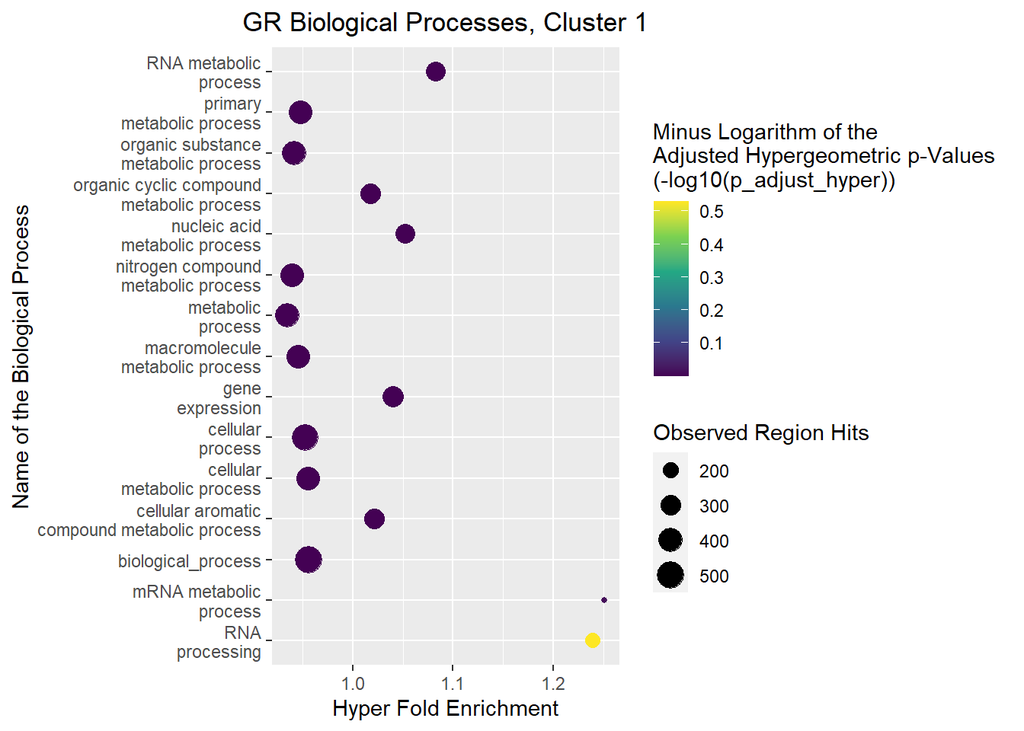

```r
res_2a <- getEnrichmentTables(job_2a)
res_2b <- getEnrichmentTables(job_2b)
res_2c <- getEnrichmentTables(job_2c)
res_2d <- getEnrichmentTables(job_2d)
res_2e <- getEnrichmentTables(job_2e)
res_2f <- getEnrichmentTables(job_2f)

ggplot(head(res_1a,15), aes(fold_enrichment_hyper, reorder(breakStrings(description, 10, "\n"), p_adjust_hyper), size=observed_region_hits, color=-log10(p_adjust_hyper))) + geom_point() + scale_color_viridis_c() + labs(title = "GR Biological Processes, Cluster 1", x = "Hyper Fold Enrichment", y = "Name of the Biological Process", colour = "Minus Logarithm of the \nAdjusted Hypergeometric p-Values \n(-log10(p_adjust_hyper))", size = "Observed Region Hits") + theme(plot.title = element_text(hjust = 0.5))
```

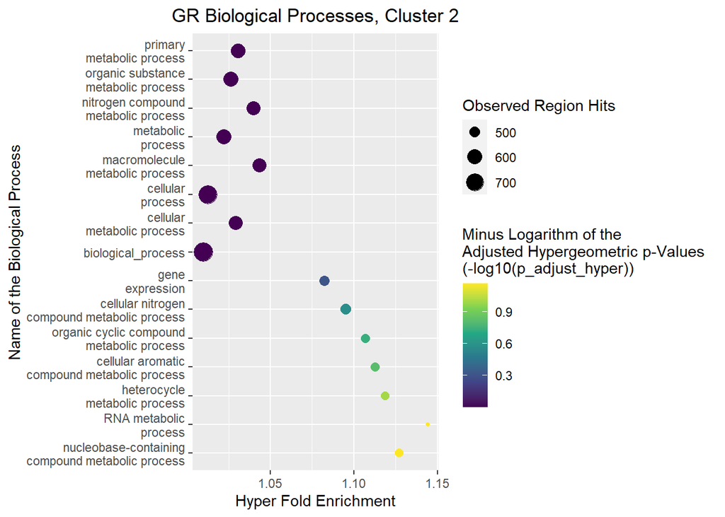

```r
ggplot(head(res_1b,15), aes(fold_enrichment_hyper, reorder(breakStrings(description, 10, "\n"), p_adjust_hyper), size=observed_region_hits, color=-log10(p_adjust_hyper))) + geom_point() + scale_color_viridis_c() + labs(title = "GR Biological Processes, Cluster 2", x = "Hyper Fold Enrichment", y = "Name of the Biological Process", colour = "Minus Logarithm of the \nAdjusted Hypergeometric p-Values \n(-log10(p_adjust_hyper))", size = "Observed Region Hits") + theme(plot.title = element_text(hjust = 0.5))
```

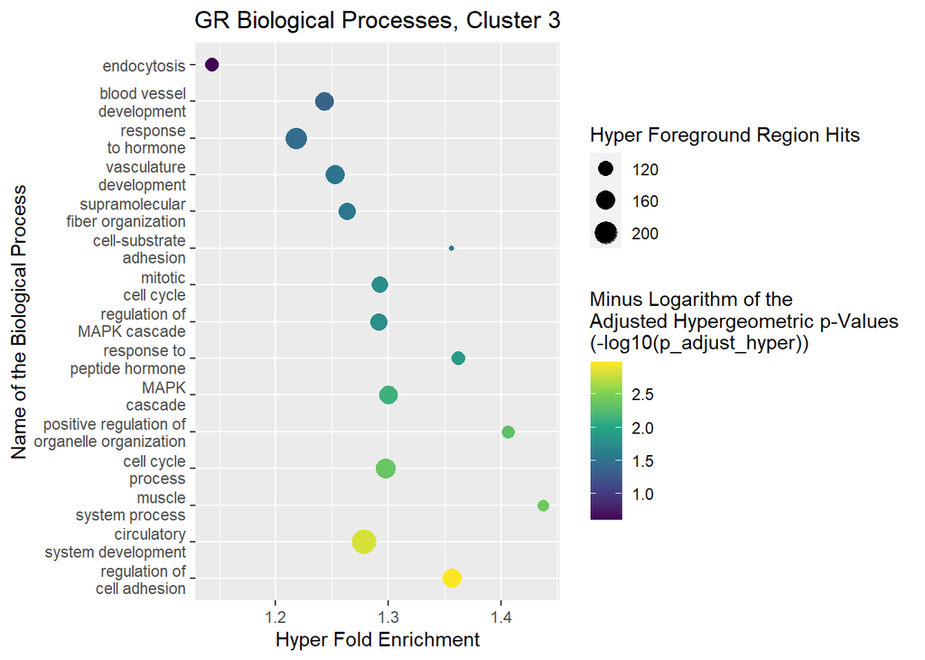

```r
ggplot(head(res_1c,15), aes(fold_enrichment_hyper, reorder(breakStrings(description, 10, "\n"), p_adjust_hyper), size=observed_region_hits, color=-log10(p_adjust_hyper))) + geom_point() + scale_color_viridis_c() + labs(title = "GR Biological Processes, Cluster 3", x = "Hyper Fold Enrichment", y = "Name of the Biological Process", colour = "Minus Logarithm of the \nAdjusted Hypergeometric p-Values \n(-log10(p_adjust_hyper))", size = "Hyper Foreground Region Hits") + theme(plot.title = element_text(hjust = 0.5)) # res_1c is empty
```

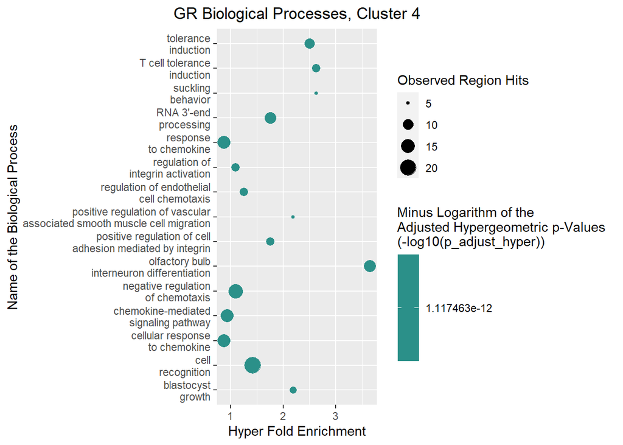

```r
ggplot(head(res_1d,15), aes(fold_enrichment_hyper, reorder(breakStrings(description, 10, "\n"), p_adjust_hyper), size=observed_region_hits, color=-log10(p_adjust_hyper))) + geom_point() + scale_color_viridis_c() + labs(title = "GR Biological Processes, Cluster 4", x = "Hyper Fold Enrichment", y = "Name of the Biological Process", colour = "Minus Logarithm of the \nAdjusted Hypergeometric p-Values \n(-log10(p_adjust_hyper))", size = "Observed Region Hits") + theme(plot.title = element_text(hjust = 0.5))
```

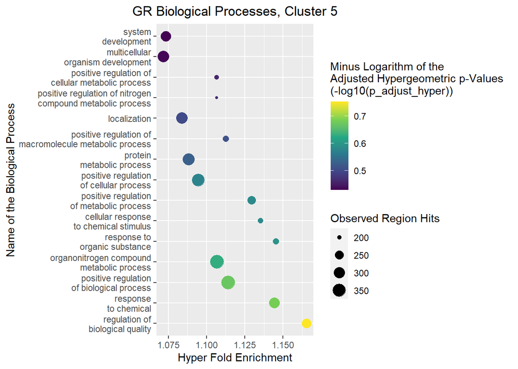

```r
ggplot(head(res_1e,15), aes(fold_enrichment_hyper, reorder(breakStrings(description, 10, "\n"), p_adjust_hyper), size=observed_region_hits, color=-log10(p_adjust_hyper))) + geom_point() + scale_color_viridis_c() + labs(title = "GR Biological Processes, Cluster 5", x = "Hyper Fold Enrichment", y = "Name of the Biological Process", colour = "Minus Logarithm of the \nAdjusted Hypergeometric p-Values \n(-log10(p_adjust_hyper))", size = "Observed Region Hits") + theme(plot.title = element_text(hjust = 0.5))
```

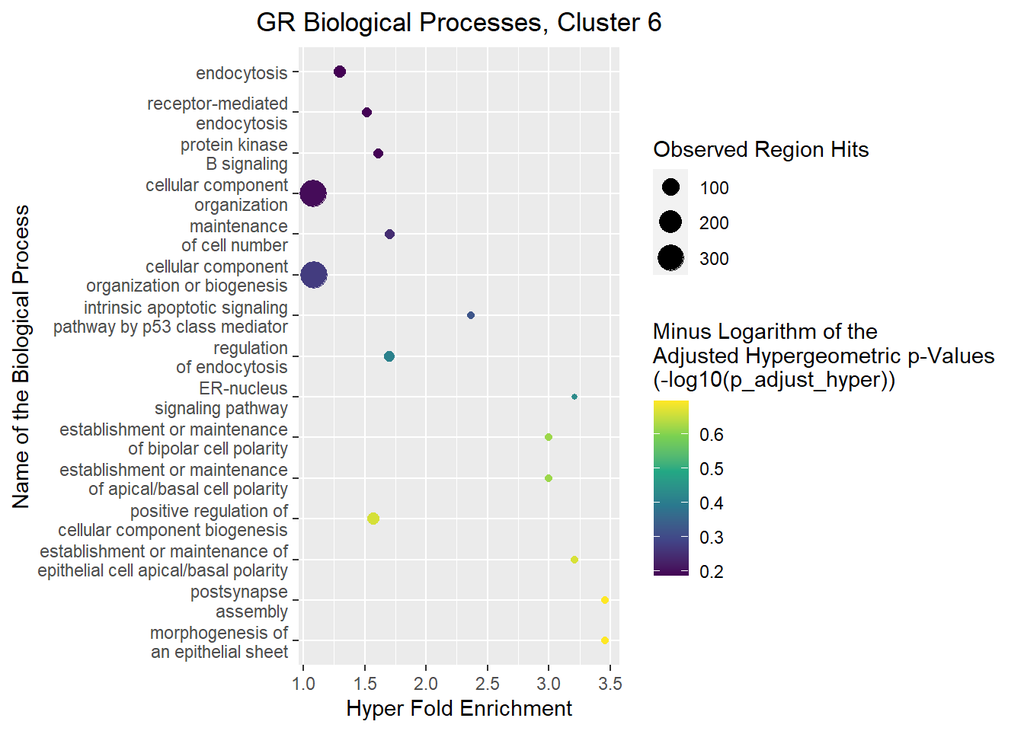

```r
ggplot(head(res_1f,15), aes(fold_enrichment_hyper, reorder(breakStrings(description, 10, "\n"), p_adjust_hyper), size=observed_region_hits, color=-log10(p_adjust_hyper))) + geom_point() + scale_color_viridis_c() + labs(title = "GR Biological Processes, Cluster 6", x = "Hyper Fold Enrichment", y = "Name of the Biological Process", colour = "Minus Logarithm of the \nAdjusted Hypergeometric p-Values \n(-log10(p_adjust_hyper))", size = "Observed Region Hits") + theme(plot.title = element_text(hjust = 0.5))
```

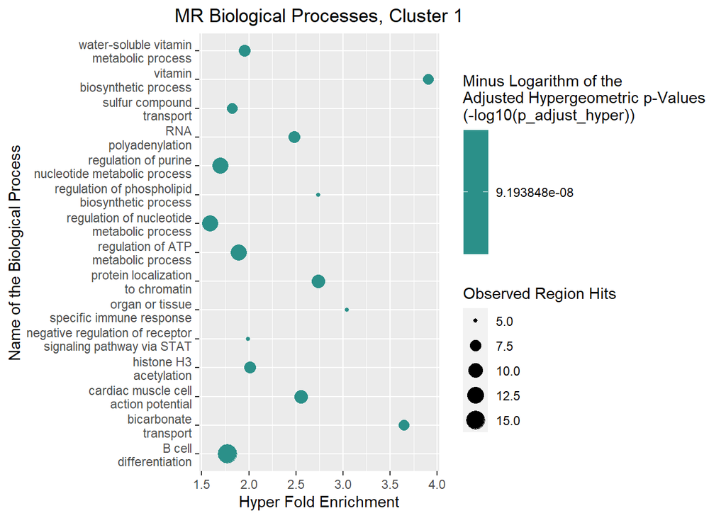

```r
ggplot(head(res_2a,15), aes(fold_enrichment_hyper, reorder(breakStrings(description, 10, "\n"), p_adjust_hyper), size=observed_region_hits, color=-log10(p_adjust_hyper))) + geom_point() + scale_color_viridis_c() + labs(title = "MR Biological Processes, Cluster 1", x = "Hyper Fold Enrichment", y = "Name of the Biological Process", colour = "Minus Logarithm of the \nAdjusted Hypergeometric p-Values \n(-log10(p_adjust_hyper))", size = "Observed Region Hits") + theme(plot.title = element_text(hjust = 0.5))
```

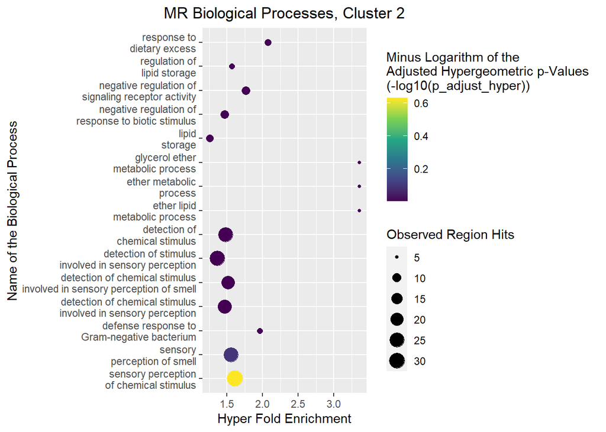

```r
ggplot(head(res_2b,15), aes(fold_enrichment_hyper, reorder(breakStrings(description, 10, "\n"), p_adjust_hyper), size=observed_region_hits, color=-log10(p_adjust_hyper))) + geom_point() + scale_color_viridis_c() + labs(title = "MR Biological Processes, Cluster 2", x = "Hyper Fold Enrichment", y = "Name of the Biological Process", colour = "Minus Logarithm of the \nAdjusted Hypergeometric p-Values \n(-log10(p_adjust_hyper))", size = "Observed Region Hits") + theme(plot.title = element_text(hjust = 0.5))#res_2b is also empty
```

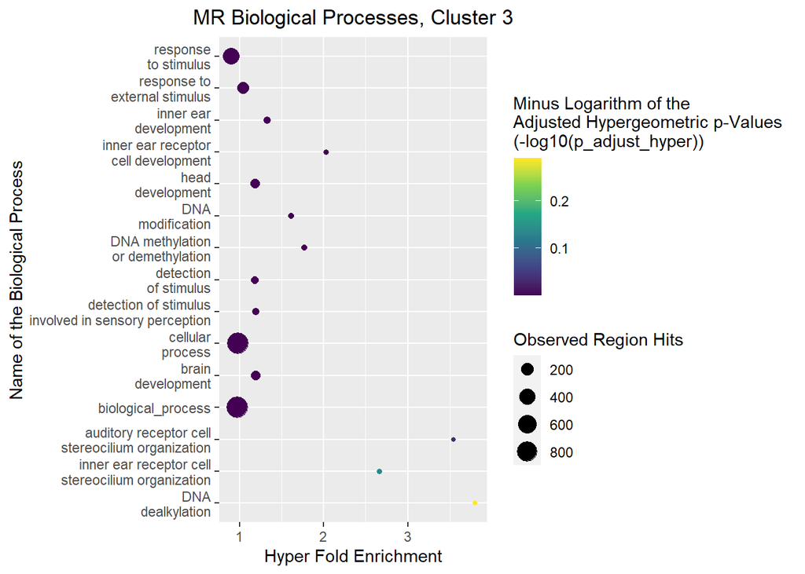

```r
ggplot(head(res_2c,15), aes(fold_enrichment_hyper, reorder(breakStrings(description, 10, "\n"), p_adjust_hyper), size=observed_region_hits, color=-log10(p_adjust_hyper))) + geom_point() + scale_color_viridis_c() + labs(title = "MR Biological Processes, Cluster 3", x = "Hyper Fold Enrichment", y = "Name of the Biological Process", colour = "Minus Logarithm of the \nAdjusted Hypergeometric p-Values \n(-log10(p_adjust_hyper))", size = "Observed Region Hits") + theme(plot.title = element_text(hjust = 0.5))#res_2c is empty as well
```

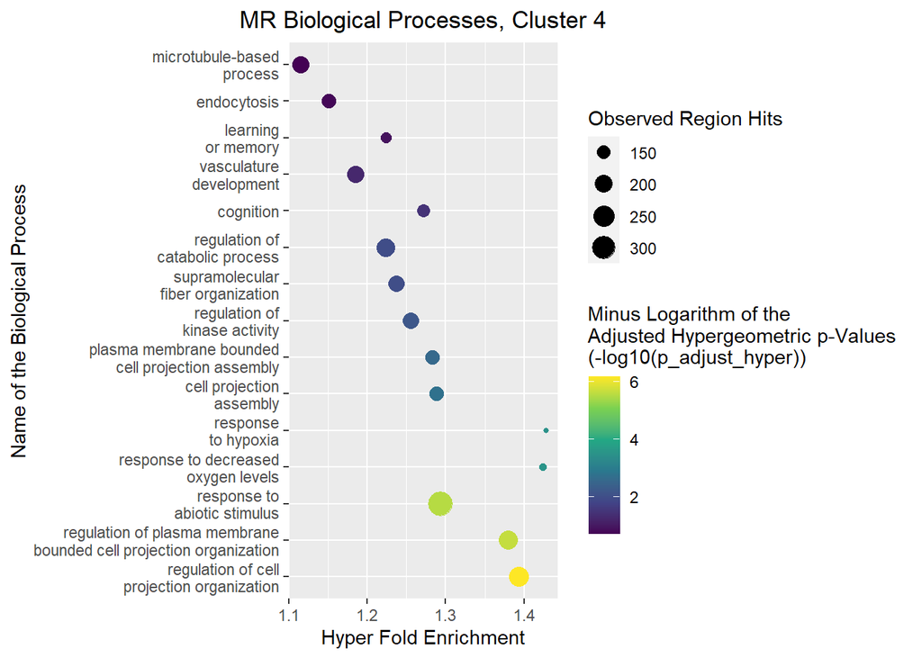

```r
ggplot(head(res_2d,15), aes(fold_enrichment_hyper, reorder(breakStrings(description, 10, "\n"), p_adjust_hyper), size=observed_region_hits, color=-log10(p_adjust_hyper))) + geom_point() + scale_color_viridis_c() + labs(title = "MR Biological Processes, Cluster 4", x = "Hyper Fold Enrichment", y = "Name of the Biological Process", colour = "Minus Logarithm of the \nAdjusted Hypergeometric p-Values \n(-log10(p_adjust_hyper))", size = "Observed Region Hits") + theme(plot.title = element_text(hjust = 0.5))
```

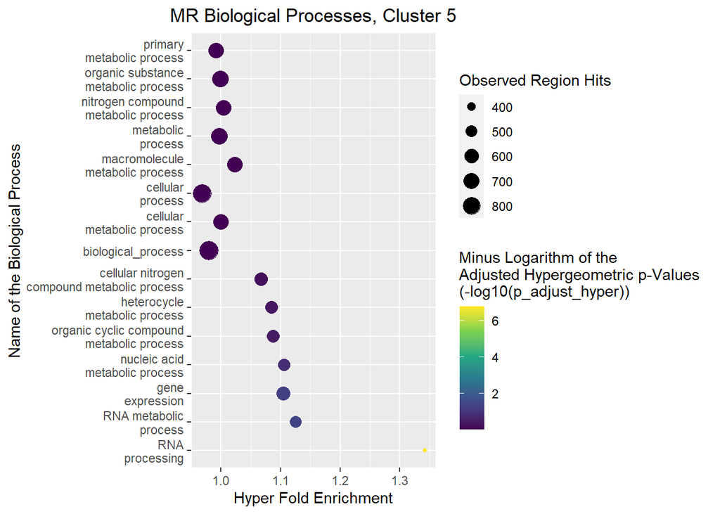

```r
ggplot(head(res_2e,15), aes(fold_enrichment_hyper, reorder(breakStrings(description, 10, "\n"), p_adjust_hyper), size=observed_region_hits, color=-log10(p_adjust_hyper))) + geom_point() + scale_color_viridis_c() + labs(title = "MR Biological Processes, Cluster 5", x = "Hyper Fold Enrichment", y = "Name of the Biological Process", colour = "Minus Logarithm of the \nAdjusted Hypergeometric p-Values \n(-log10(p_adjust_hyper))", size = "Observed Region Hits") + theme(plot.title = element_text(hjust = 0.5))
```

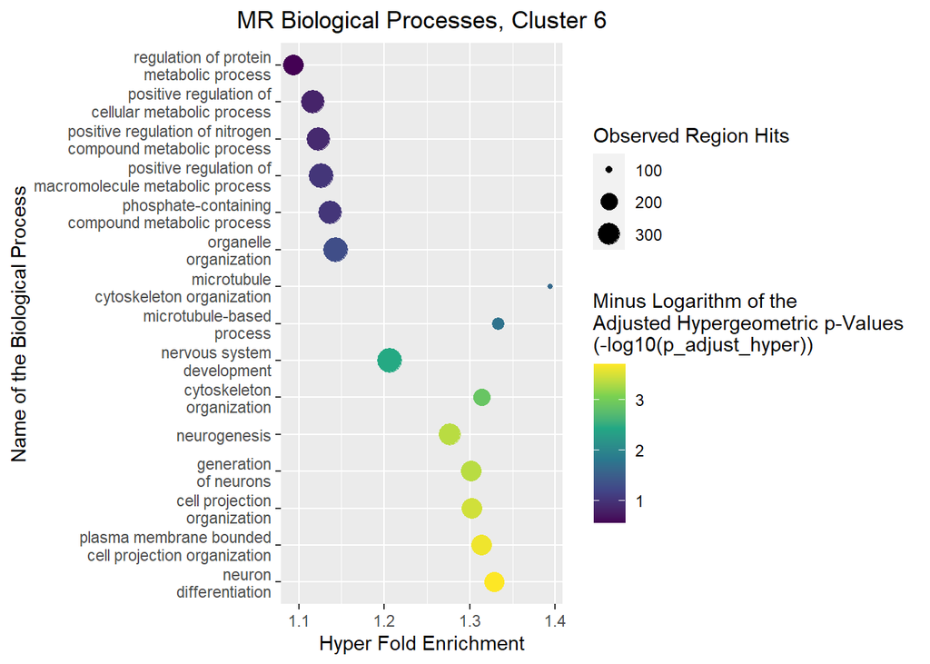

```r
ggplot(head(res_2f,15), aes(fold_enrichment_hyper, reorder(breakStrings(description, 10, "\n"), p_adjust_hyper), size=observed_region_hits, color=-log10(p_adjust_hyper))) + geom_point() + scale_color_viridis_c() + labs(title = "MR Biological Processes, Cluster 6", x = "Hyper Fold Enrichment", y = "Name of the Biological Process", colour = "Minus Logarithm of the \nAdjusted Hypergeometric p-Values \n(-log10(p_adjust_hyper))", size = "Observed Region Hits") + theme(plot.title = element_text(hjust = 0.5))
```

There we conducted our GO-analysis using the same clusters that had before been plotted in the heatmaps that investigated gene enrichment in the previous document.

The functions that were found for the different clusters can be seen in the plots above.

For example, GO-analysis on MR cluster 6 reveals important functions in neurogenesis and neuron differentiation, which are known to be inhibited during stress (Briones & Gould, 2019).

Compared to the previous GO analysis, that was performed without any cluster, with this one we were able to extrapolate some functions that are highly relevant in our context, but that did not seem important previously, probably because the set of regions that we are analysing globally might not be necessarily super specific for those functions. In the genome there are a huge number of genes, and specific functions are represented by a very low percentage of these. By grouping regions based on their similarity, and analysing those groups, those functions can emerge. The findings of the paper, that were confirmed by the previous GO analysis, might be correct, but these biological processes might not be the most relevant in a context of stress, or just before the start of the active phase, when glucocorticoids are usually released.